# Analysis of pTSA1-mCh-tTSA1 RT-qPCR data sets with two experimental repllicates

Jamie Auxillos

22/07/2020

# Experimental information

The strains used here are:

- pTSA1-mCherry-tTSA1 wild type (WT)
- pTSA1-mCherry-tTSA1 mod0 (mod0)
- pTSA1-mCherry-tTSA1 modA (modA)
- pTSA1-mCherry-tTSA1 modB (modB)
- pTSA1-mCherry-tTSA1 modC (modC)
- pTSA1-mCherry-tTSA1 modD (modD)
- pTSA1-mCherry-tTSA1 modE (modE)
- POT1-ccdb

For each strain three biological replicates were grown. Strains were grown overnight to saturation in a 24 well plate (1 ml) in a shaking incubator set at 250 rpm and at 30C. The next day, the OD600 of these cultures were measured and diluted down to an OD600 of 0.2 in an 8 ml culture in a 12 column deep well plate. The samples were grown to an OD600 of 0.5-0.6 for ~3-4 hours. Cells were harvested by centrifugation (3500 rpm for 3 minutes) in a 15 ml falcon tube. The cells were lysed and the RNA was extracted using the following RNA extraction protocol https://www.protocols.io/view/column-based-zymo-rna-extraction-bbcgiitw. The RNA was treated with TurboDNase and used as the template for reverse transcription and qPCR using the following protocol https://github.com/ewallace/protocols/blob/master/RTqPCR_Agilent_Lightcycler_Protocol.md. We are using the probes mCh-7, URA3-ORF, RPS3-ORF and PGK1-ORF for the qPCR experiment. For each +RT cDNA sample, we have three technical replicates, and one technical replicate for the -RT sample.

## Load plate and summarise information

```r
# read my plates

plate_exp_1 <- read_tsv(here("raw_data_analysis/data/raw_qpcr/20200731-pTSA1-tTSA1mod-n1-ct.txt"),skip=1) %>%
    mutate(well=Pos,cq=Cp) %>%
    left_join(plateplan_exp_1)

plate_exp_2 <- read_tsv(here("raw_data_analysis/data/raw_qpcr/20200801-pTSA1-tTSA1mod-n2-ct.txt"),skip=1) %>%
    mutate(well=Pos,cq=Cp) %>%
    left_join(plateplan_exp_2)

plates <- bind_rows(plate_exp_1,plate_exp_2)

summary(plates)
```

```
##  Include            Color           Pos                Name
##  Mode:logical   Min.   :  255   Length:768         Length:768
##  TRUE:768       1st Qu.:  255   Class :character   Class :character
##                 Median :  255   Mode  :character   Mode  :character
##                 Mean   : 8976
##                 3rd Qu.:  255
##                 Max.   :65280
##
##        Cp        Concentration     Standard  Status            well
##  Min.   : 8.66   Mode:logical   Min.   :0   Mode:logical   Length:768
##  1st Qu.:10.45   NA's:768       1st Qu.:0   NA's:768       Class :character
##  Median :11.37                  Median :0                  Mode  :character
##  Mean   :14.14                  Mean   :0
##  3rd Qu.:12.44                  3rd Qu.:0
##  Max.   :35.93                  Max.   :0
##  NA's   :103
##        cq           well_row      well_col    sample_id
##  Min.   : 8.66   A      : 48   1      : 32   Length:768
##  1st Qu.:10.45   B      : 48   2      : 32   Class :character
##  Median :11.37   C      : 48   3      : 32   Mode  :character
##  Mean   :14.14   D      : 48   4      : 32
##  3rd Qu.:12.44   E      : 48   5      : 32
##  Max.   :35.93   F      : 48   6      : 32
##  NA's   :103     (Other):480   (Other):576
##                       strain      pro_mCh            promoter
##  pTSA1-mCherry-tTSA1_WT  : 96   Length:768         Length:768
##  pTSA1-mCherry-tTSA1_mod0: 96   Class :character   Class :character
##  pTSA1-mCherry-tTSA1_modA: 96   Mode  :character   Mode  :character
##  pTSA1-mCherry-tTSA1_modB: 96
##  pTSA1-mCherry-tTSA1_modC: 96
##  pTSA1-mCherry-tTSA1_modD: 96
##  (Other)                 :192
##    mCherry             bio_rep      ter_mod           terminator
##  Length:768         BioRep1:128   Length:768         Length:768
##  Class :character   BioRep2:128   Class :character   Class :character
##  Mode  :character   BioRep3:128   Mode  :character   Mode  :character
##                     BioRep4:128
##                     BioRep5:128
##                     BioRep6:128
##
##    construct      exp_rep      remove        prep_type tech_rep    target_id
##  modE   : 96   ExpRep1:384   Mode :logical   +RT:576   1:384    mCh-7   :192
##  modD   : 96   ExpRep2:384   FALSE:768       -RT:192   2:192    URA3-ORF:192
##  modC   : 96                                           3:192    RPS3-ORF:192
##  modB   : 96                                                    PGK1-ORF:192
##  modA   : 96
##  (Other):192
##  NA's   : 96
```

### Plotting unnormalised data for pTSA1 strains

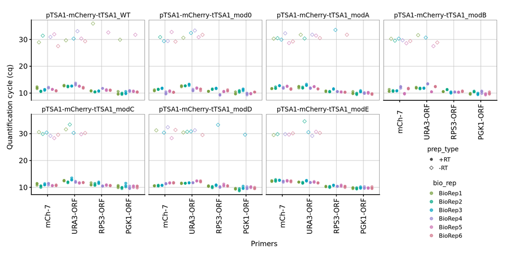

### Plotting unnormalised data for control strains (pTSA1-mCherry-tTSA1_WT and POT1-ccdB)

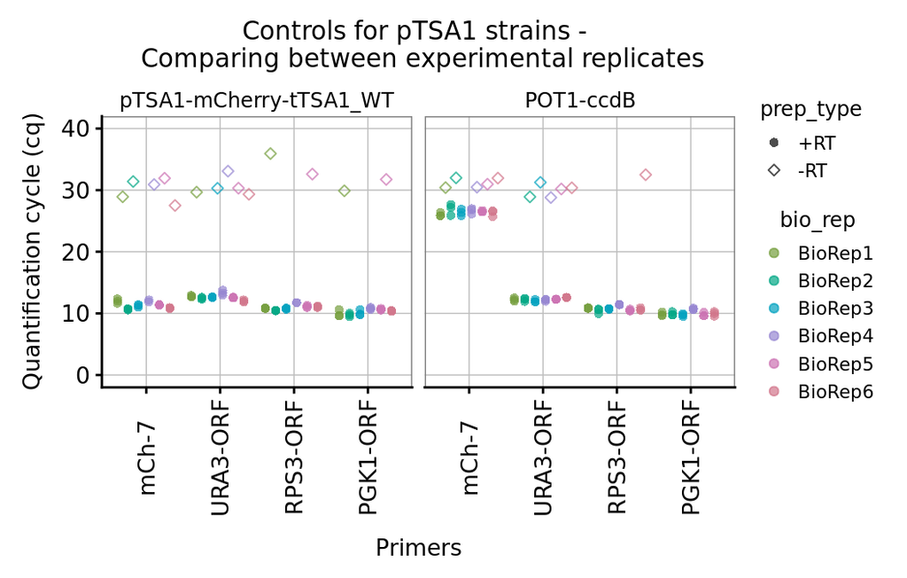

## Loading amplification and melt curve pTSA1 data

```r
platecurve_exp_1 <- read_tsv(
  here("raw_data_analysis/data/raw_qpcr/20200731-pTSA1-tTSA1mod-n1.txt"),
  skip=2,
  col_names=c("well", "SID", "program_no", "segment", "cycle", "time", "temperature", "fluor_raw")) %>%
  debaseline() %>%
  left_join(plateplan_exp_1)

platecurve_exp_2 <- read_tsv(
  here("raw_data_analysis/data/raw_qpcr/20200801-pTSA1-tTSA1mod-n2.txt"),
  skip=2,
  col_names=c("well", "SID", "program_no", "segment", "cycle", "time", "temperature", "fluor_raw")) %>%
  debaseline() %>%
  left_join(plateplan_exp_2)

platecurve <- bind_rows(platecurve_exp_1, platecurve_exp_2)

platesamp  <- platecurve %>% filter(program_no == 2)
platesmelt <- platecurve %>%
  filter(program_no != 2) %>%
  getdRdTall() %>%
  filter(temperature >= 61)

head(platesamp)
```

```
## # A tibble: 6 x 26
##   well  SID   program_no segment cycle   time temperature fluor_raw fluor_base
##   <chr> <chr>      <dbl>   <dbl> <dbl>  <dbl>       <dbl>     <dbl>      <dbl>
## 1 A1    Samp…          2       2     1 233150        59.9      0.88       0.91
## 2 A1    Samp…          2       2     2 272300        59.8      0.89       0.91
## 3 A1    Samp…          2       2     3 311434        59.8      0.9        0.91
## 4 A1    Samp…          2       2     4 350550        59.8      0.9        0.91
## 5 A1    Samp…          2       2     5 389634        59.8      0.91       0.91
## 6 A1    Samp…          2       2     6 428834        59.8      0.91       0.91
## # … with 17 more variables: fluor_signal <dbl>, well_row <fct>, well_col <fct>,
## #   sample_id <chr>, strain <fct>, pro_mCh <chr>, promoter <chr>,
## #   mCherry <chr>, bio_rep <fct>, ter_mod <chr>, terminator <chr>,
## #   construct <fct>, exp_rep <fct>, remove <lgl>, prep_type <fct>,
## #   tech_rep <fct>, target_id <fct>
```

```r
head(platesmelt)
```

```
## # A tibble: 6 x 27
##   well  SID   program_no segment cycle   time temperature fluor_raw fluor_base
##   <chr> <chr>      <dbl>   <dbl> <dbl>  <dbl>       <dbl>     <dbl>      <dbl>
## 1 A1    Samp…          3       1     1 1.79e6        61.2      5.73       0.54
## 2 A1    Samp…          3       1     1 1.78e6        61.2      5.26       0.91
## 3 A1    Samp…          3       1     1 1.78e6        61.4      5.23       0.91
## 4 A1    Samp…          3       1     1 1.79e6        61.4      5.72       0.54
## 5 A1    Samp…          3       1     1 1.78e6        61.6      5.21       0.91
## 6 A1    Samp…          3       1     1 1.79e6        61.6      5.7        0.54
## # … with 18 more variables: fluor_signal <dbl>, well_row <fct>, well_col <fct>,
## #   sample_id <chr>, strain <fct>, pro_mCh <chr>, promoter <chr>,
## #   mCherry <chr>, bio_rep <fct>, ter_mod <chr>, terminator <chr>,
## #   construct <fct>, exp_rep <fct>, remove <lgl>, prep_type <fct>,
## #   tech_rep <fct>, target_id <fct>, dRdT <dbl>
```

### Amplification Curves of POT1-ccdB strains (all bioreps) against all 4 Targetids (mCh-7, PGK1-ORF, RPS3-ORF, URA3-ORF) (pTSA1)

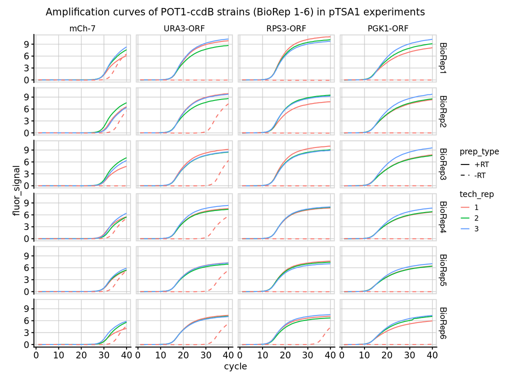

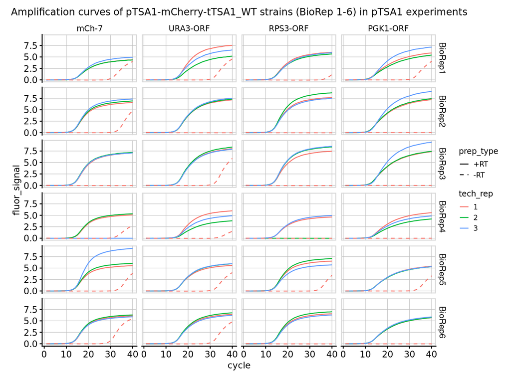

### Melt Curves of POT1-ccdB and pTSA1-mCherry-tTSA1_WT strains (all bioreps) against all 4 Targetids (mCh-7, PGK1-ORF, RPS3-ORF, URA3-ORF) (pTSA1)

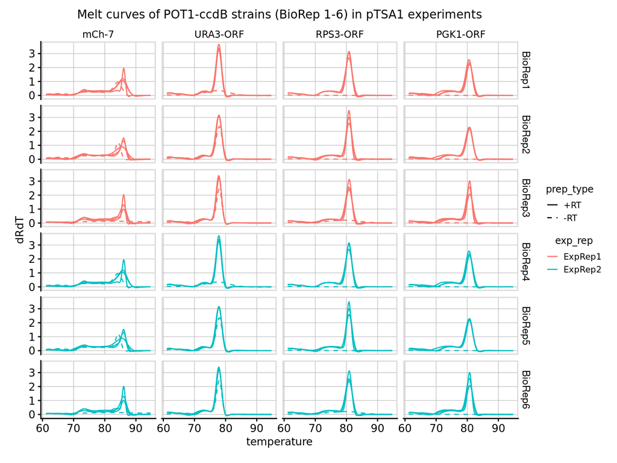

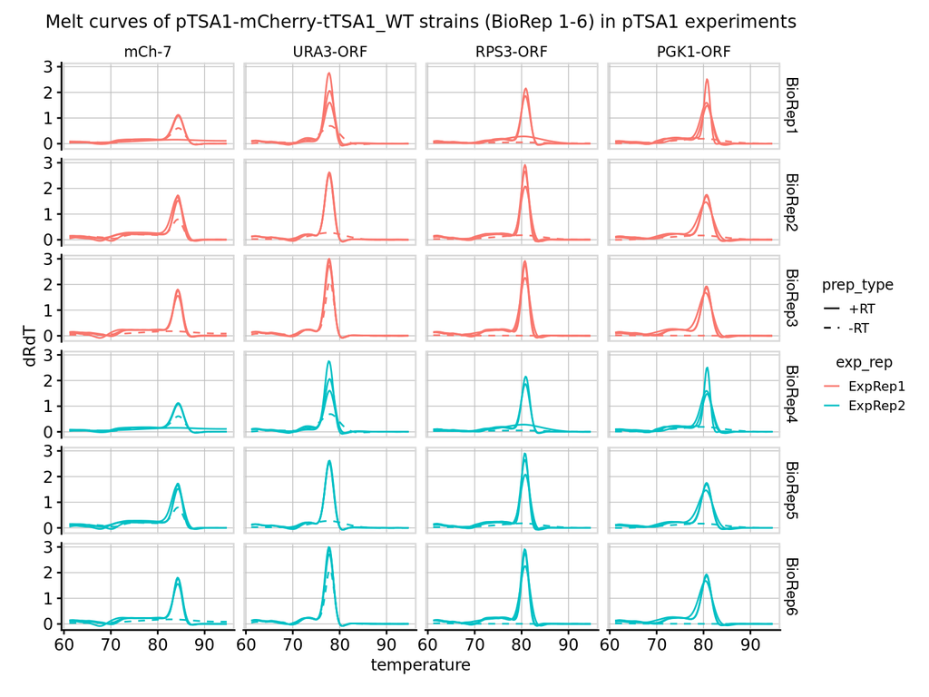